# Comentários e cultura

Igor Matheus Castor Diniz Pinheiro

```r
dados = read_csv(
    here::here("data/participation-per-country.csv"),
    col_types = cols(
        .default = col_double(),
        site = col_character(),
        country = col_character(),
        geo = col_character(),
        four_regions = col_character(),
        eight_regions = col_character(),
        six_regions = col_character(),
        `World bank income group 2017` = col_character()
    )
) %>%
    filter(usuarios > 200)
glimpse(dados)
```

```
## Observations: 121
## Variables: 21
## $ site                           <chr> "StackOverflow", "StackOverflow",…
## $ country                        <chr> "Argentina", "Australia", "Austri…
## $ PDI                            <dbl> 49, 36, 11, 80, 65, 69, 70, 39, 6…
## $ IDV                            <dbl> 46, 90, 55, 20, 75, 38, 30, 80, 2…
## $ MAS                            <dbl> 56, 61, 79, 55, 54, 49, 40, 52, 2…
## $ UAI                            <dbl> 86, 51, 70, 60, 94, 76, 85, 48, 8…
## $ usuarios                       <dbl> 2798, 12313, 2518, 2558, 4275, 10…
## $ responderam_prop               <dbl> 0.5357398, 0.6133355, 0.6310564, …
## $ perguntaram_prop               <dbl> 0.5210865, 0.5897832, 0.5933280, …
## $ editaram_prop                  <dbl> 0.09256612, 0.14699911, 0.1493248…
## $ comentaram_prop                <dbl> 0.25339528, 0.33395598, 0.3502780…
## $ GNI                            <dbl> NA, 59570, 48160, 840, 44990, 116…
## $ Internet                       <dbl> 51.0, 79.5, 79.8, 5.0, 78.0, 45.0…
## $ EPI                            <dbl> 59.02, NA, 63.21, NA, 61.21, 49.9…
## $ geo                            <chr> "arg", "aus", "aut", "bgd", "bel"…
## $ four_regions                   <chr> "americas", "asia", "europe", "as…
## $ eight_regions                  <chr> "america_south", "east_asia_pacif…
## $ six_regions                    <chr> "america", "east_asia_pacific", "…
## $ Latitude                       <dbl> -34.00000, -25.00000, 47.33333, 2…
## $ Longitude                      <dbl> -64.00000, 135.00000, 13.33333, 9…
## $ `World bank income group 2017` <chr> "Upper middle income", "High inco…
```

Estamos interessados na relação entre quanto as pessoas de diferentes países comentam em questões dos outros. A proporção das pessoas do país que comentou nas questões de outros está medido na variável `comentaram_prop`.

Considerando essa variável, queremos examinar a relação entre ela e o quão hierárquicas são as relações em um país (`PDI`). Queremos também levar em conta o quanto as pessoas daquele país têm acesso à Internet (`Internet`) e qual o tamanho da base de dados que detectamos daquele país (`usuarios`).

## Examinando essa relação

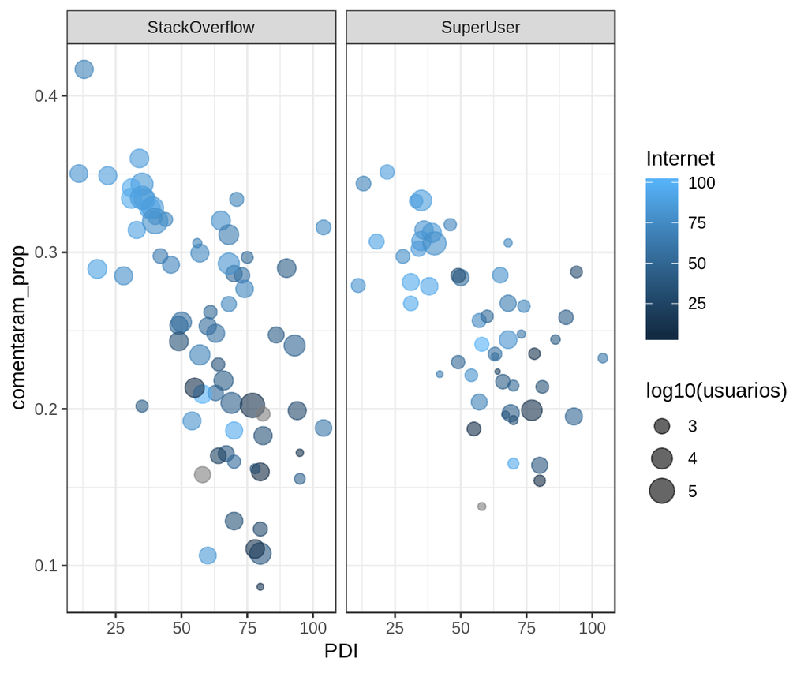

```r
dados %>%
    ggplot(aes(x=PDI, y=comentaram_prop, size=log10(usuarios),  color=Internet))+
    geom_point(alpha = .6)+
    facet_wrap(~site)
```

Através desta visualização, que não julgo ser a melhor de todas devido a limitação gráfica, podemos perceber que o site StackOverflow possui um maior número de “bolinhas” claras caracterizando um maior número de usuários com internet, bem como um maior número de bolinha maiores caracterizando que os usuários no geral. De modo geral para ambos os casos podemos perceber que quanto menor o PDI maior será o numero de usuários com internet e maior será o número de usuarios. Outra ánalise que podemos extrair do gráfico é que quanto menor o PDI maior é a proporção de comentário.

## Outras formas de ver

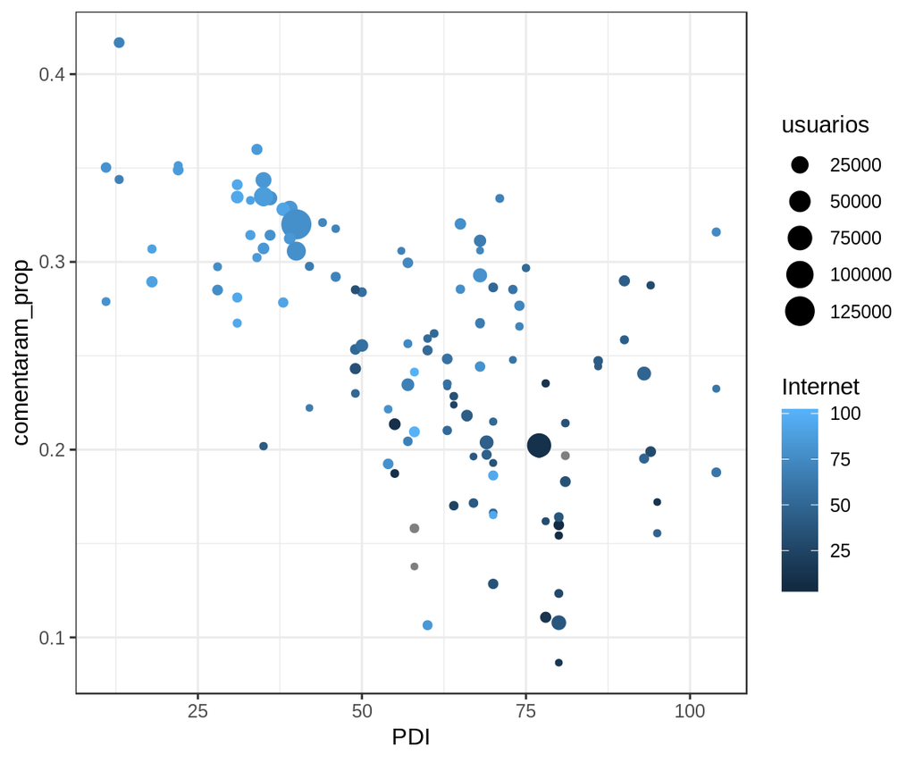

```r
dados %>%
    ggplot(aes(x=PDI, y=comentaram_prop,size=usuarios,color = Internet))+
    geom_point()
```

Esta visualização mostrou que quanto maior o número de pessoas com Internet maior será a proporção de comentarios e menor o número de PDI, mas não se enquadra numa boa visualização pois existem dados “escondidos” ou que podem estar sendo sobrepostos, por exemplo, “bolinhas” menores sendo sobrepostas por “bolinhas” maiores. Outro fator que dificulta a visualização é a não separação por dominios(Site).

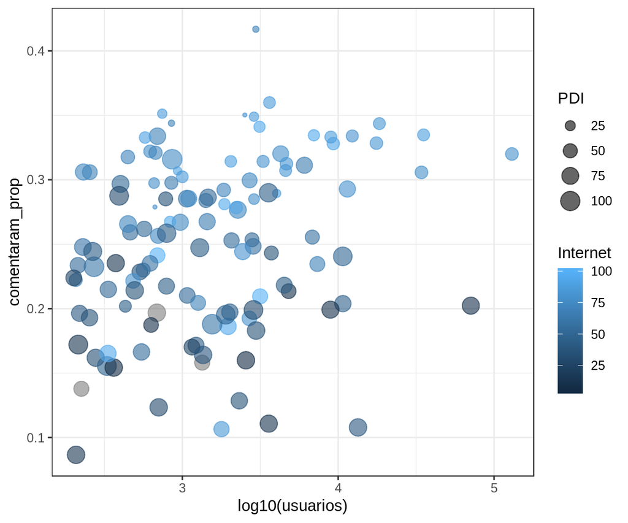

```r
dados %>%
    ggplot(aes(x=log10(usuarios), y=comentaram_prop,size=PDI,color = Internet))+
    geom_point(alpha = .6)
```

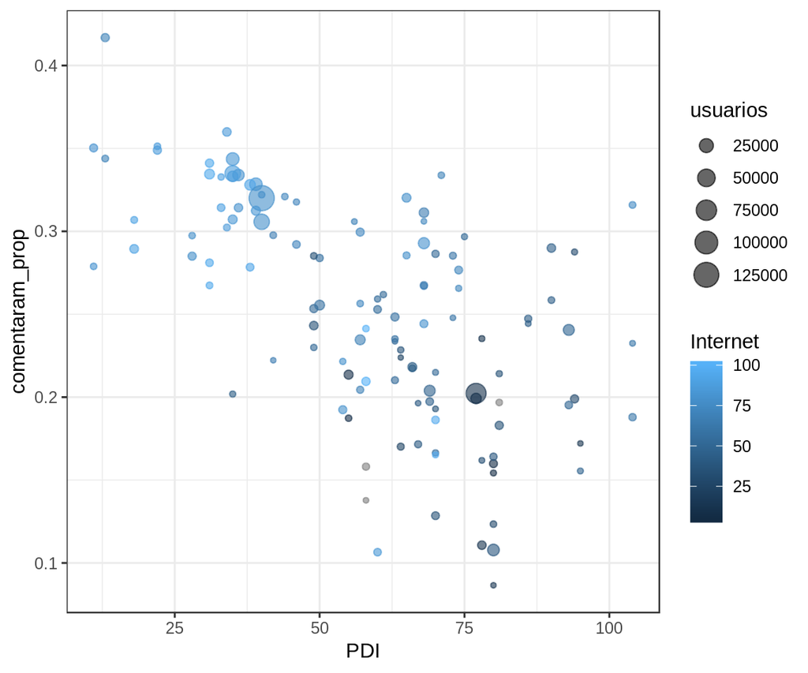

```r
dados %>%
    ggplot(aes(x=PDI, y=comentaram_prop, size=usuarios,  color=Internet))+
    geom_point(alpha = .6)
```

Esta visualização mostrou que quanto maior o número de pessoas com Internet maior será a proporção de comentarios e menor o número de PDI, mas não se enquadra numa boa visualização pois não há a separação por dominios(Site).

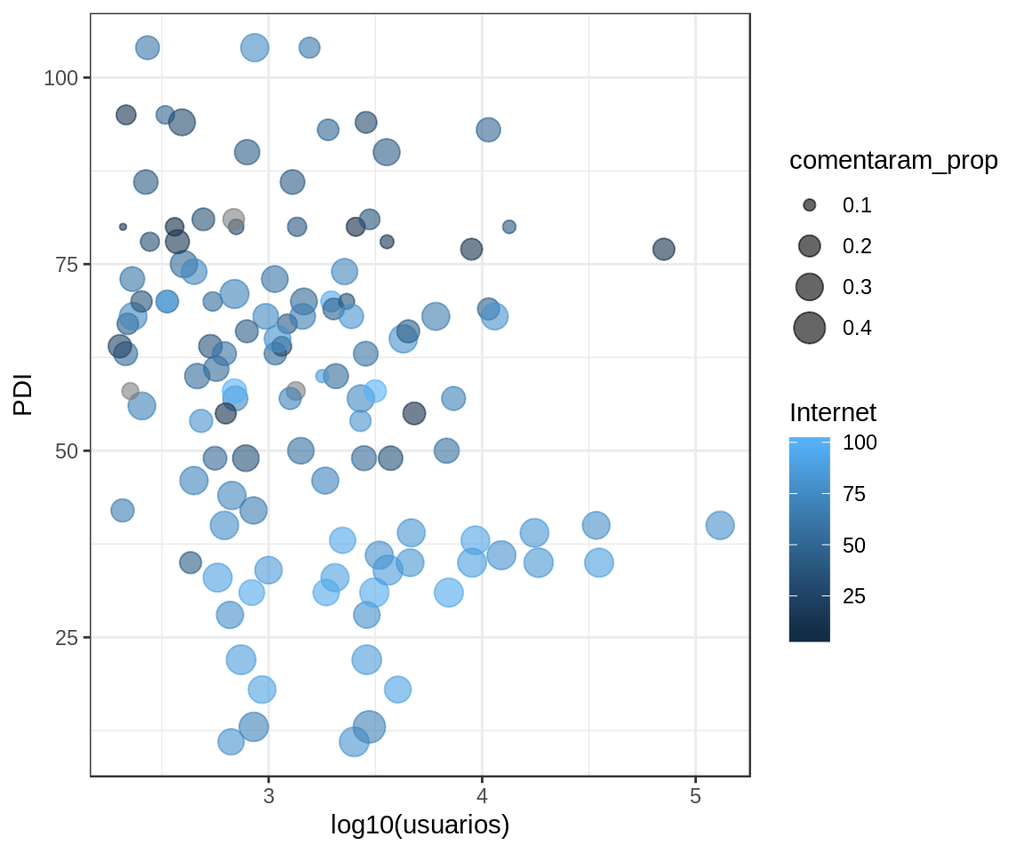

```r
dados %>%
    ggplot(aes(x=log10(usuarios), y=PDI, size=comentaram_prop,  color=Internet))+
    geom_point(alpha = .6)
```

Visualização um tanto quanto confusa, a escolha das variáveis para os eixos podem confundir bastante o entendimento de usuário inexperiente.

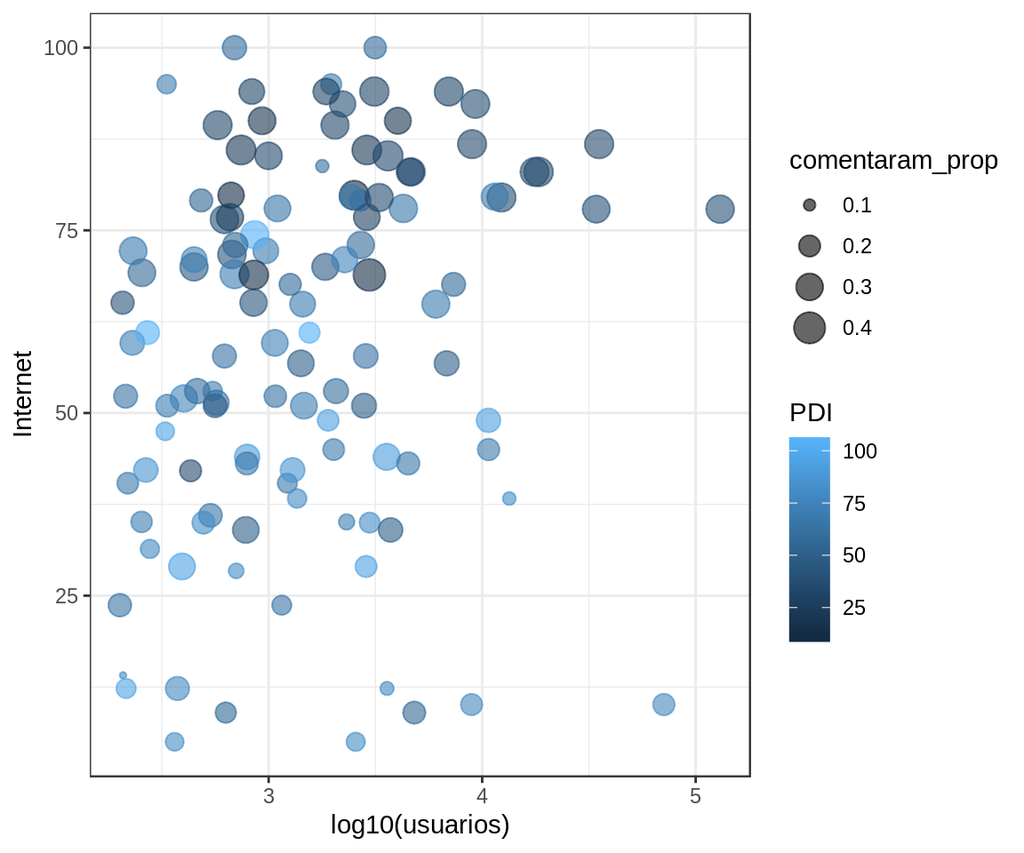

```r
dados %>%
    ggplot(aes(x=log10(usuarios), y=Internet, size=comentaram_prop,  color=PDI))+
    geom_point(alpha = .6)
```

Em seguida, faça 5 visualizações que usem as mesmas variáveis e também pontos, mas que sejam **menos eficazes** que a que você escolheu acima.

## Bônus

Inclua o continente dos países (`six_regions`) na visualização.

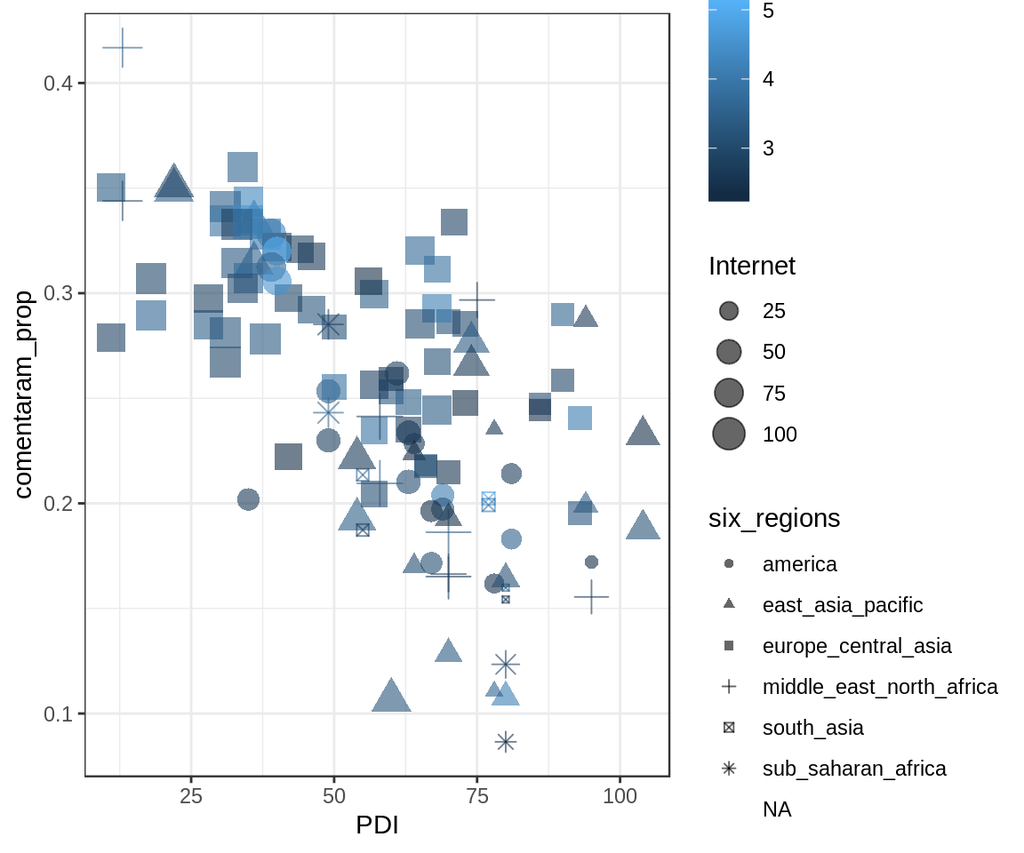

```r
dados %>%
    ggplot(aes(x=PDI, y=comentaram_prop, size=Internet,  color=log10(usuarios), shape=six_regions))+
    geom_point(alpha = .6)
```

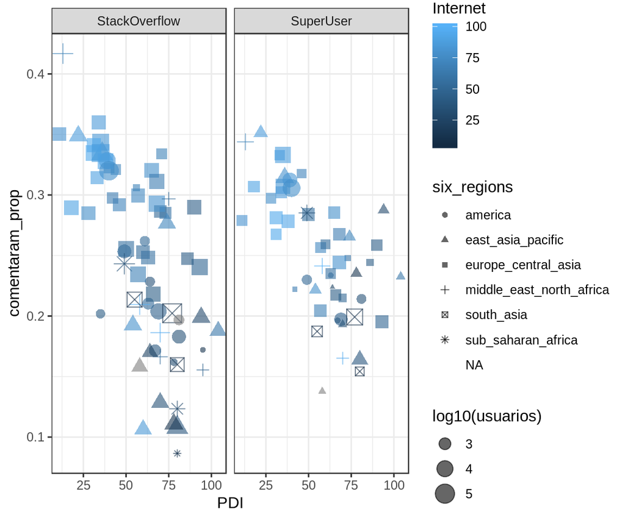

```r
dados %>%
    ggplot(aes(x=PDI, y=comentaram_prop, size=log10(usuarios),  color=Internet,shape=six_regions))+
    geom_point(alpha = .6)+
    facet_wrap(~site)
```

Associando a melhor visualização escolhida no primeiro gráfico com as regiões caracterizadas nas formas, podemos perceber claramente que a Europa central e Asia são as mais atuantes. Essa relação vale para os dois dominios.